# Master's Degree in Particle Physics and Cosmos UC-UIMP

# M1991- Statistics and data analysis. Course 2019-2020

### Homework: Monte Carlo Methods and Simulations.

### 1. Errors on fit parameters

Application to error propagation to a model which follows a decay $1/t$ [1].

First, a simulation of the data is made for 100 points.

Then the data is fitted to a curve.

```r
## library necessary to make plots
library(Hmisc)
```

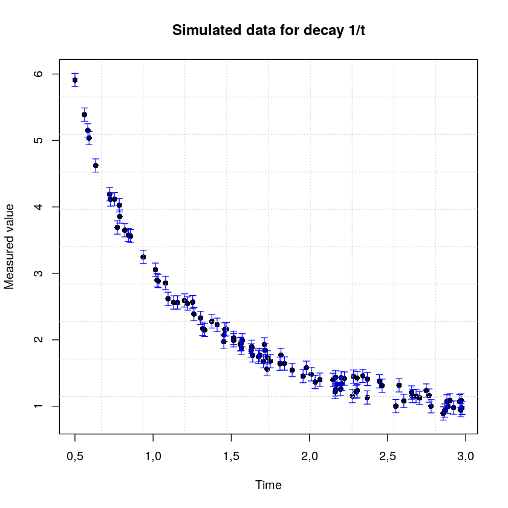

```r
#### simulation of the data

N <- 100

xMeas <- runif(N, 0.5,3.0)
yTrue = 1.5/xMeas
sError = 0.1
yMeas = yTrue + rnorm(N, yTrue, sError)

errplot1 <- errbar(xMeas, yMeas,
                   yplus= yMeas+sError,
                   yminus = yMeas-sError,
                  xlab = 'Time', ylab = 'Measured value',
                  errbar.col = 'blue', lty = 1)

grid(nx = 10, ny = 10, col = "lightgray", lty = "dotted")
title(main='Simulated data for decay 1/t')
```

```r
### fitt of the data

decay <- function(x, params) {
    a <- params[1]
    b <- params[2]
    d <- a*x**b
    return(d)
}

## function to minimize
fun.to.minimize <- function(params,x,y,var){
        a <- params[1]
        b <- params[2]
        flost <- a*x^b
        output <- sum((y-flost)^2/var^2)
        return(output)
    }

## initial conditions

a0 <- 2
b0 <- -2

## fitting
solution <- optim(c(a0,b0), fun.to.minimize, x=xMeas, y=yMeas, var=sError)
new.a <- solution$par[1]
new.b <- solution$par[2]


solution
```

**$par**

1. 3,00486000461863

2. -0,995523532809078

**$value**

83,7387283025166

**$counts**

**function**

65

**gradient**

<NA>

**$convergence**

0

**$message**

NULL

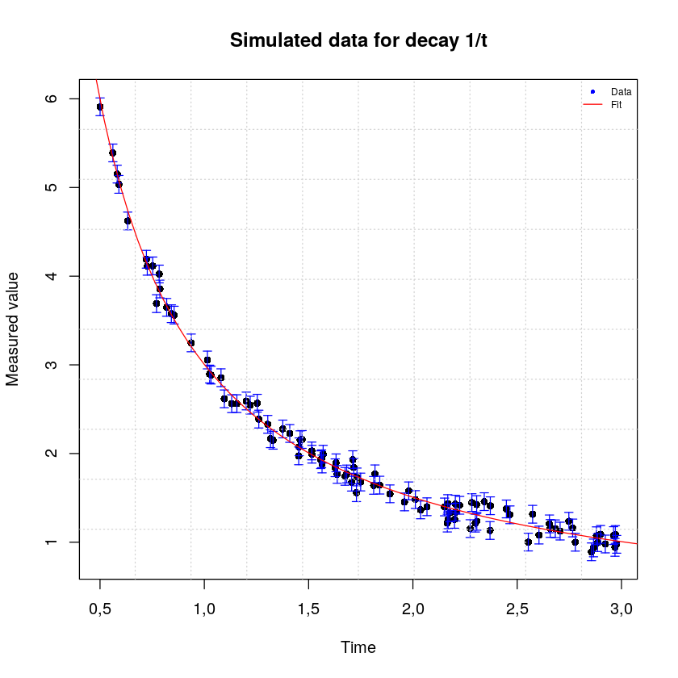

```r
## ploting the fit

errplot1 <- errbar(xMeas, yMeas,
                   yplus= yMeas+sError,
                   yminus = yMeas-sError,
                  xlab = 'Time', ylab = 'Measured value',
                  errbar.col = 'blue', lty = 1)

grid(nx = 10, ny = 10, col = "lightgray", lty = "dotted")
title(main='Simulated data for decay 1/t')

curve(decay(x, c(new.a,new.b)), from=0,to=4 ,col='red',add=T)
#curve(decay(x, c(a0,b0)), from=0, to=4, col='green', add=T) #curve with initial parameters
legend("topright",c("Data", "Fit"), col=c("blue", "red"),
       pch=c(16,NA), lty=c(NA,1), cex=0.6, bty="n")
```

From the previous fit, It can be seen that the value of the parameters are: $p1 \approx 3$, $p2 \approx -1$.

Now, a set of data is generated in order to compute many values for the parameters involved.

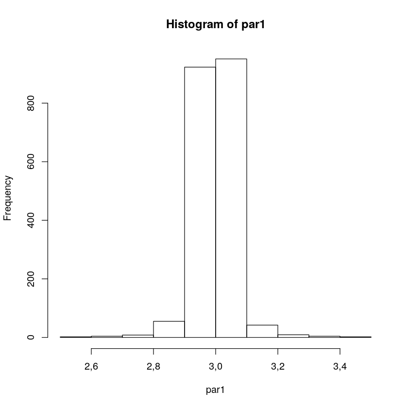

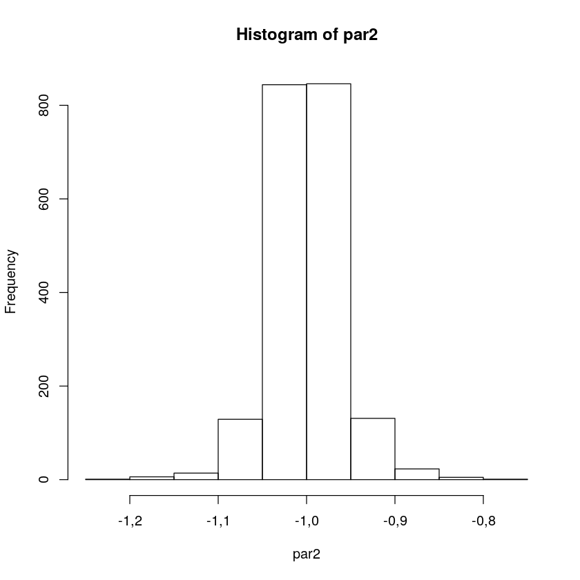

```r
trial <- 10
m <- 2000  ## number of iterations

par1 <- c()  ## parameter 1
par2 <- c()  ## parameter 2

for (i in 1:m){
    xTrial = runif(trial, 0.5,3.0);
    yGen = 1.5/xTrial;
    yTrial = yGen + rnorm(trial, yGen, sError);
    fit <- optim(c(a0,b0), fun.to.minimize, x=xTrial, y=yTrial, var=sError);
    #lines(xTrial, decay(xTrial, c(fit$par[1],fit$par[2])), col='green')
    par1 <- append(par1, fit$par[1])
    par2 <- append(par2, fit$par[2])
}


hist(par1)

hist(par2)
```

From the histograms, the values of the parameters are consistent with these obtained from the optimization. MC method was useful to simulate the data for a decay $1/t$.

The relation between such parameters can be seen from a power-law plot:

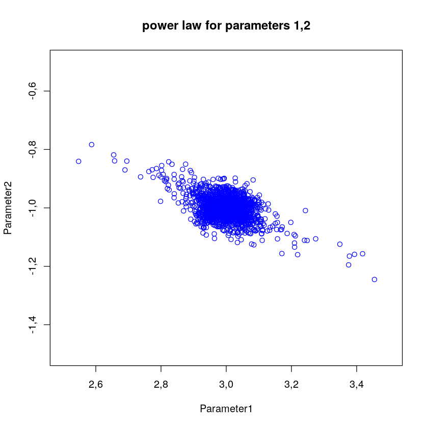

```r
plot(x = par1,y = par2,
   xlab = "Parameter1",
   ylab = "Parameter2",
   xlim = c(2.5, 3.5),
   ylim = c(-1.5, -.5),
   main = "power law for parameters 1,2",
   col='blue'
)
```

### 2. Simple example of MC application

`a)` An initial particle with energy $E$ can be decomposed into two particles (photons, for example).

Assuming an error in measurements of sigma/energy=0.1

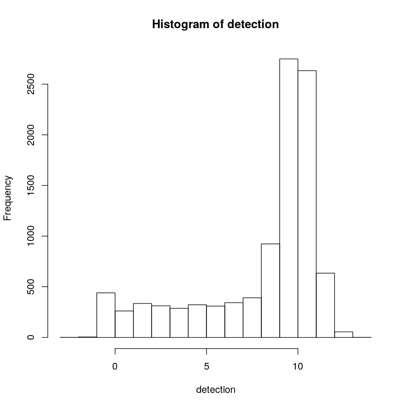

```r
N=10000

## energy of the particles 1,2
energy1=runif(N,0,10)
energy2=10-energy1

p1=runif(N)
p2=runif(N)

## error in measurements sigma/energy=0.1

error1=rnorm(N,energy1,0.1*e1)
error2=rnorm(N,energy2,0.1*e2)


detection = ifelse(p1<0.8,error1,0)+ifelse(p2<0.8,error2,0)
hist(detection)
```

The histogram shows an addition to the 'noise' for the two taller colums.

`b)` Application to error propagation to Newton's Law [2]:

$$ F = G \frac{M_1 M_2}{r^2} $$

Given the following values and uncertainties:

$G$ is considered as an exact value:

$G = 6.674 \times 10^{-11}$ m$^3$/kgs$^2$

```
[1] "SD of the force"
```

5,34902852859029e-09

```
[1] "mean of the force"
```

2,85085785519384e-07

**16%**

2,79850374455309e-07

**50%**

2,8499429669047e-07

**84%**

2,90437484442205e-07

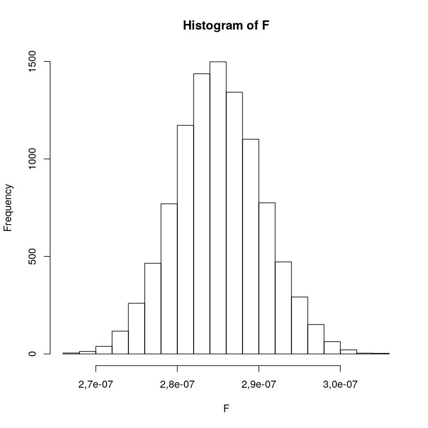

```r
## N iterations
N = 10000

## values and uncertainties

G <- 6.674E-11

m1 <- rnorm(N, 4000, 0.5)
m2 <- rnorm(N, 3000, 0.1)
r <- rnorm(N, 53, 0.5)


## force F

force <- function(m1, m2, r){
    f = G*m1*m2/r^2
    return(f)
}



## calculating the force

F <- force(m1, m2, r)

print('SD of the force')
sd(F)

print('mean of the force')
mean(F)


## quantiles of the Force
quantile(F,prob=c(0.16,0.5,0.84))

hist(F)
```

Now, the distribution function for $F$ is:

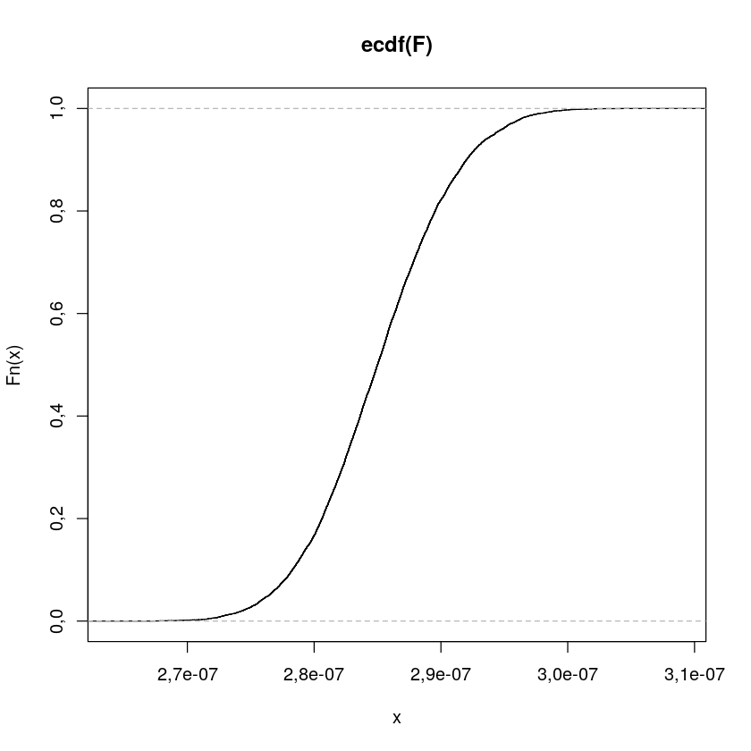

```r
fdistf= ecdf(F)

plot(fdistf)
```

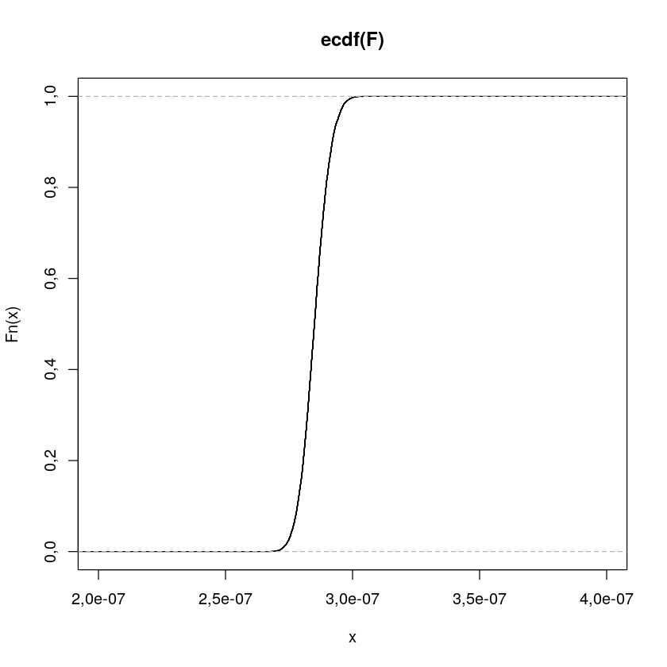

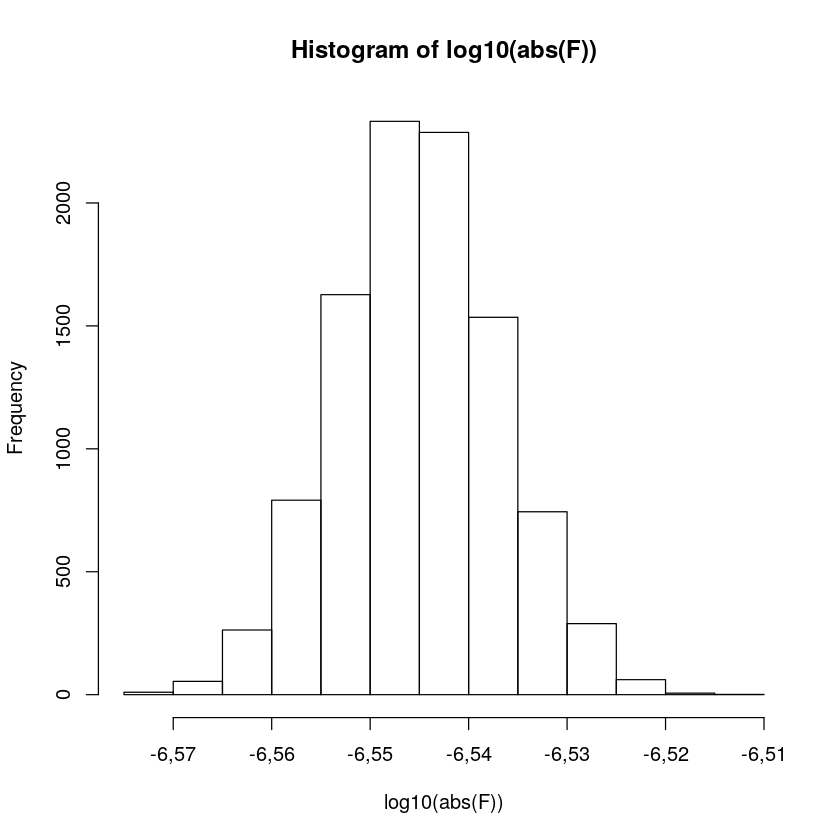

```r
plot(fdistf, ylim=c(0,1), xlim=c(2E-7,4E-7))    #intervalo de confianza al 68%

hist(log10(abs(F))) #shows scale
```

### References:

1. Clarkson, W. (2014). HOWTO estimate parameter-errors using Monte Carlo. From: http://www-personal.umd.umich.edu/~wiclarks/AstroLab/HOWTOs/NotebookStuff/MonteCarloHOWTO.html
1. https://wwwstaff.ari.uni-heidelberg.de/tsapras/pub/pycourse/montecarlo.html
1. R Core Team (2013). R: A language and environment for statistical computing. R Foundation for Statistical Computing, Vienna, Austria. URL http://www.R-project.org/.
1. Matorras, F. *Monte Carlo Methods*. (Statistics and Data Analysis, UC Master on Particle Physics and the Cosmos,December 2019-january 2020)